# What should a default prior keep flat?

Testing one regression coefficient with an objective Bayes factor, under three priors that all respect valid correlation matrices

Author

D.M. Kloppenburg

Published

November 4, 2026

**Abstract.** With one predictor, the natural objective prior for testing a regression coefficient is flat on its correlation. With several predictors, valid correlation matrices force a choice of what stays flat as predictors are added: each partial correlation, the multiple correlation *R*, or *R*². The three choices form one family, in which *R*² follows a Beta(*a*, 1) distribution with *a* = *k*/2, ½ or 1. We implemented all three with exact Bayes factors and a Stan model and tested them side by side against the criteria of Bayarri et al. (2012), simulation-based calibration, operating characteristics and coherence with the joint model; 134 of 135 checks passed. All three priors are computed correctly and meet the formal criteria, but they behave differently. Under flat *R* and flat *R*², the test of one coefficient drifts as other predictors are added, and it does not become more accurate as it does so. At 20 predictors all three tests rank datasets identically (AUC = .701), yet flat *R* leaves 92% of true nulls undecided, whereas flat partial *r* confirms 88%. Only the conditional test under flat partial *r* is the Bayes factor of one joint model; under flat *R* the corresponding restricted model is not a proper model. We recommend flat partial *r* and state its costs.

# 1 Introduction

Default (“objective”) Bayes factors are widely used to test whether one predictor matters in a regression, for instance through the JZS prior in the BayesFactor package and in JASP. A default prior is meant to express nothing beyond what is possible. With one predictor, the obvious choice is Jeffreys’ prior, which is flat on the correlation. With *k* predictors there is no single obvious choice, and the choice has a consequence that is easy to miss. It determines whether the evidence about one coefficient depends on how many *other* predictors are in the model.

This report asks which of three candidate defaults should be used. It answers the question by testing all three on equal terms.

# 2 Methods

## 2.1 Three priors, one family

Not every correlation-based quantity can be flat at once. Study 00 shows this by drawing random valid correlation matrices of (*y*, *x*₁ … *x*ₖ). If each **partial correlation** (= the correlation of *y* with one predictor after removing the other predictors from both) is kept flat, *R*² grows with *k*. If *R* or *R*² is kept flat, each partial correlation shrinks with *k*. The three versions define the three priors compared here.

| Prior | *R*² prior | What stays flat as predictors are added | Known as |
| --- | --- | --- | --- |
| flat partial r | Beta(*k*/2, 1) | each partial correlation | LKJ(1); `stan_lm` with η = 1 |
| flat R | Beta(½, 1) | the multiple correlation *R* | — |
| flat R-squared | Beta(1, 1) | *R*² | — |

For every *k*, each simulated version is flat on its own scale (study 00, checks F1–F3, 200,000 matrices per *k*). All three priors spread the total explained variance in a uniformly random direction over the predictors (so one predictor’s share follows Beta(½, (*k* − 1)/2)), and all three are mixtures of Zellner *g*-priors (Liang et al., 2008).

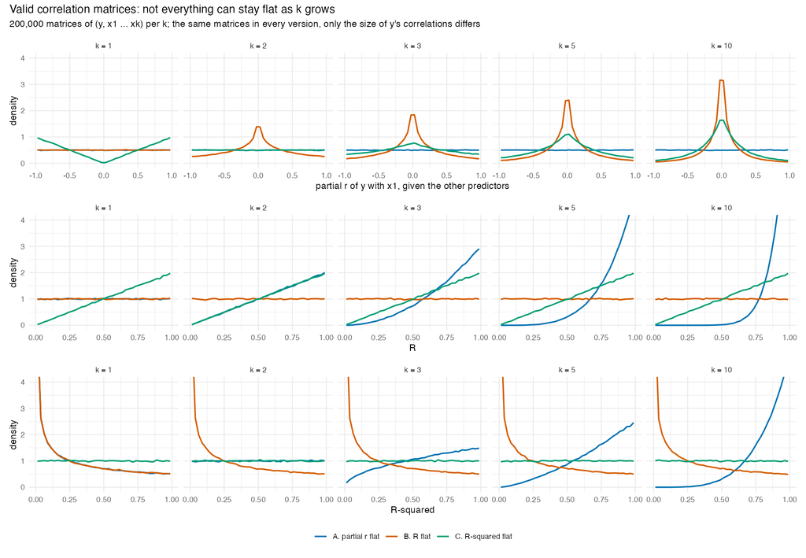

Study 00. What valid correlation matrices force, per k: the three versions share the matrices and differ only in what is kept flat.

## 2.2 Tests

Two tests of one coefficient are compared. The **conditional test** (= the test of the coefficient’s partial correlation against zero, using the prior that the joint prior implies for it) looks at that coefficient alone. The **joint test** compares the model with the predictor against the model without it. JZS (Cauchy prior with scale 0.354) and Zellner–Siow (scale 1) serve as reference methods.

The behaviour of the test is studied mainly in study 06. It crosses 72 designs: *k* = 2, 5, 10 or 20 predictors; *n* = 50, 200 or 1,000; predictor correlations of 0, .30 or .70; and the other coefficients either sparse (one of them 0.3, the rest zero) or dense (all 0.1). In each design the tested coefficient *x*₁ has a true slope of 0, 0.1 or 0.2, with 200 datasets per cell. Predictors have unit variance and the noise has standard deviation 1, so a slope of 0.1 is a change of 0.1 noise standard deviations per standard deviation of the predictor.

## 2.3 Validation

The validation consists of twelve studies. Each study’s criteria are fixed in its script before it runs:

| Question | Criterion and source | Studies |
| --- | --- | --- |
| Is it computed correctly? | Bayes factors against `integrate()`, brute-force sampling and a second derivation; Stan prior draws (KS); simulation-based calibration (Talts et al., 2018) | 01, 02, 05 |
| Does it meet the default-prior criteria? | Predictive matching, invariance, information, model-selection and intrinsic consistency (Bayarri et al., 2012) | 02, 08 |
| How does the test of one coefficient behave? | Discrimination (AUC) and what each test says at BF 3 (Schönbrodt & Wagenmakers, 2018) | 03, 04, 06, 11 |
| Is it calibrated and coherent? | Calibration on its own prior (Schad et al., 2023); the conditional test against the Savage–Dickey ratio of the joint model (Wagenmakers et al., 2010) | 10 |
| What does it cost for estimation and selection? | Prediction error, bias and coverage; variable selection | 07, 09 |

The run reported here started 2026-11-04 12:24 CET (commit 21d42dc (the uncommitted changes were to the documentation only); R version 4.6.1 (2026-06-24); CmdStan 2.40.0). Every parallel task draws from its own random stream, so the results are the same on any number of cores.

# 3 Results

## 3.1 All three are correct and meet the formal criteria

Checks per study, read from the run’s logs (studies without checks are comparisons).

| Study | Passed | Failed |
| --- | --- | --- |
| 01 prior and posterior | 19 | 0 |
| 02 bayes factor | 45 | 0 |
| 03 simulations | 2 | 0 |
| 04 matched comparison | 0 | 0 |
| 05 conditional test | 13 | 0 |
| 06 broad simulation | 0 | 0 |
| 07 estimation | 0 | 0 |
| 08 growing k | 12 | 0 |
| 09 variable selection | 5 | 0 |
| 10 calibration | 35 | 1 |
| 11 factor terms | 3 | 0 |

All three priors pass every correctness check, and all three meet every Bayarri et al. (2012) criterion that was checked: predictive matching at *n* = *k* + 1, invariance, information consistency from *n* = *k* + 3, model-selection consistency for fixed and growing *k*, and intrinsic consistency. These criteria are checked numerically in the settings the studies cover; none is proven analytically here. The closest result is the calibration check for the noise standard deviation under flat partial *r* (χ² *p* = .020, against a threshold of .01). In a separate diagnostic of the same setting, the package’s Stan model had no divergent transitions in 1,200 calibration fits. The one failed check (study 10, P4) is a property of flat *R*², discussed in Section 3.3.

## 3.2 The test of one coefficient drifts with *k*, without becoming more accurate

The three conditional tests are equally accurate, and they differ only in where they decide. Across the 72 designs of study 06, they separate true nulls from small effects (slope 0.1) equally well: at each *k* the three areas under the ROC curve (AUC) are identical (.728 at *k* = 2, .701 at *k* = 20), against .713 and .684 for JZS. At a Bayes factor of 3, each test either supports the null (BF₀₁ > 3), supports an effect (BF₁₀ > 3), or remains undecided:

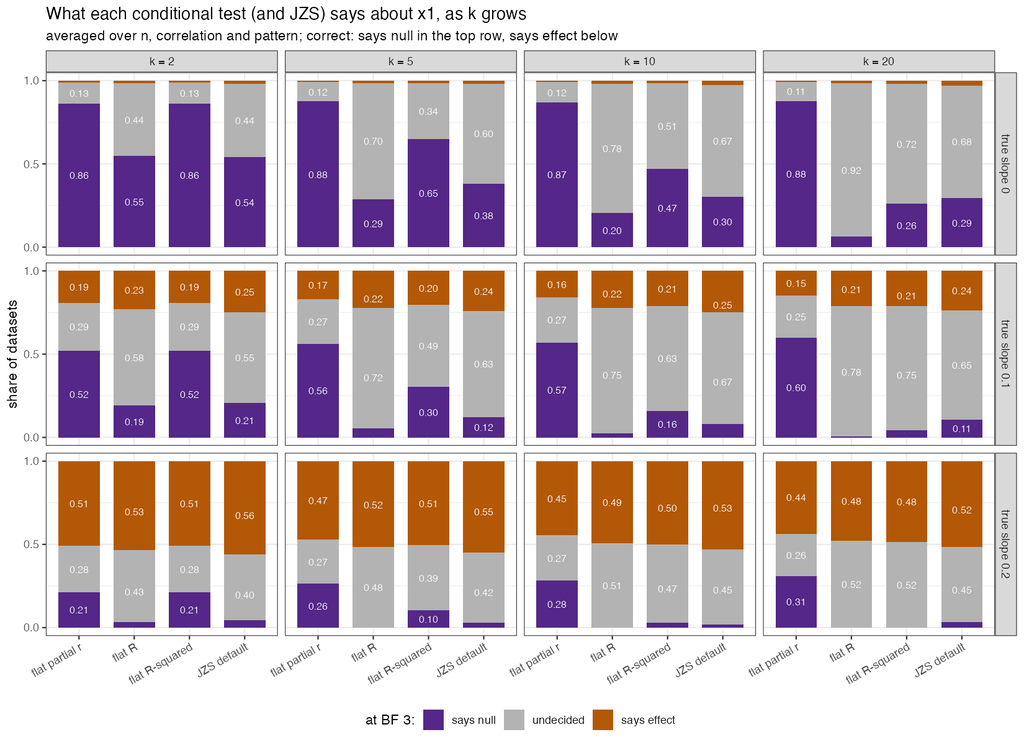

Study 06. What each test says about x1 at BF 3, by k and the true slope. Top row: the truth is null, so purple is correct; lower rows: brown is correct.

k = 20: share of datasets per answer (from study 06’s cache).

| Test | Truth | says null | undecided | says effect |
| --- | --- | --- | --- | --- |
| flat partial r conditional | slope 0 | 0.878 | 0.114 | 0.008 |
| flat partial r conditional | slope 0.1 | 0.598 | 0.255 | 0.148 |
| flat partial r conditional | slope 0.2 | 0.309 | 0.255 | 0.435 |
| flat R conditional | slope 0 | 0.062 | 0.923 | 0.015 |
| flat R conditional | slope 0.1 | 0.005 | 0.784 | 0.211 |
| flat R conditional | slope 0.2 | 0.000 | 0.522 | 0.478 |
| flat R-squared conditional | slope 0 | 0.261 | 0.721 | 0.018 |
| flat R-squared conditional | slope 0.1 | 0.042 | 0.747 | 0.211 |
| flat R-squared conditional | slope 0.2 | 0.000 | 0.515 | 0.485 |
| JZS default | slope 0 | 0.295 | 0.676 | 0.029 |
| JZS default | slope 0.1 | 0.108 | 0.654 | 0.239 |
| JZS default | slope 0.2 | 0.032 | 0.451 | 0.517 |

Under flat partial *r*, the share of true nulls that is confirmed is about the same at *k* = 2 (.86) and *k* = 20 (.88). Under flat *R* it falls from .55 to .06, under flat *R*² from .86 to .26, and under JZS from .54 to .30. Flat *R* rarely calls a small effect null (.005 at *k* = 20) because it rarely calls anything null: it leaves 92% of true nulls undecided. It finds a 0.1 effect about as often as flat *R*² (.21) and JZS (.24), and more often than flat partial *r* (.15); what it lacks is the ability to confirm nulls. Flat partial *r*’s rates for small effects shift a little with *k*: the share of 0.1 effects it calls null rises from .52 to .60, and the share of 0.2 effects it finds falls from .51 to .44. The joint tests of flat *R* and flat *R*² also depend on how much variance the other predictors explain, the shared-scale problem known as the conditional Lindley paradox (Som et al., 2016): their log Bayes factor changes by −5.2 and −5.1 per unit of the others’ *R*², against −0.5 for flat partial *r* (study 04).

## 3.3 Only flat partial *r* is one coherent model

A test of one coefficient is **coherent** when it equals the Bayes factor of the full model against the same model with that coefficient’s partial correlation fixed at zero. That Bayes factor can be estimated from the full model’s posterior with the Savage–Dickey density ratio (Wagenmakers et al., 2010). Under flat partial *r* the conditional test agrees with it to within a factor of 1.10, on the 16 of 20 datasets where the ratio can be estimated (the other four agree within three Monte Carlo standard errors). Under flat *R*² the two diverge at *k* = 8, by a factor of up to 2.40 over its 19 estimable datasets (study 10, P4, the one failed check). This reflects the prior: its partial correlations are linked through *R*², so information about the other coefficients shifts the evidence for *x*₁.

Under flat *R*, the restricted model is not a proper alternative. When the prior is conditioned on |ρ₁| < ε for shrinking ε (study 10, P7), the density of ρ₁ near zero keeps growing, and the *R*² of the other predictors goes to zero (median .001 at *k* = 3 and .003 at *k* = 8, for ε = .005). The restricted model therefore collapses to the intercept-only model. Under flat partial *r* and flat *R*², the same restriction leaves a proper model (study 10, P6).

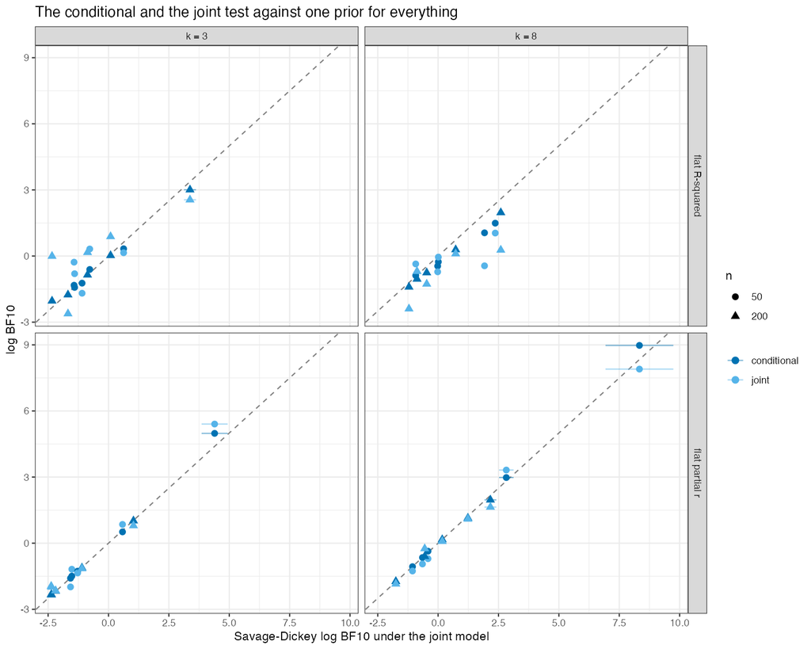

Study 10. The conditional and joint tests for x1 against the Savage-Dickey ratio of the joint model (flat partial r and flat R-squared).

## 3.4 Consistency when *k* grows with *n*

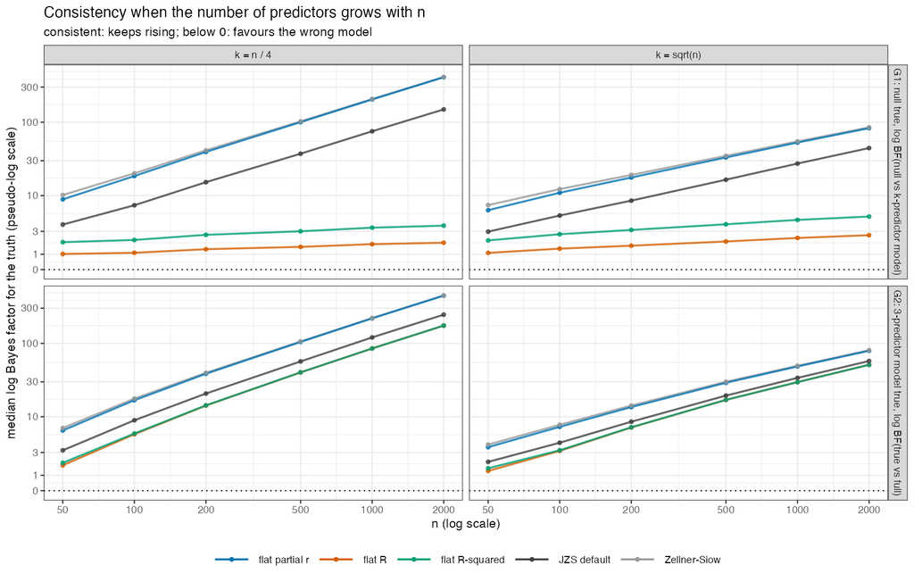

Study 08. Median log Bayes factor for the truth when k grows with n (pseudo-log scale).

All three priors are consistent when *k* grows with *n*, but the evidence accumulates at very different speeds. For a true null with 500 predictors at *n* = 2,000, the median log BF₀₁ is 407.6 under flat partial *r*, 3.7 under flat *R*² and 1.9 under flat *R* (JZS: 149.3; Zellner–Siow: 410.8).

## 3.5 Estimation and variable selection

Flat *R* and flat *R*² shrink the estimates more than flat partial *r*. This lowers their prediction error with many predictors and a small sample: at *k* = 8 and *n* = 30, their error is 0.37–0.77 and 0.42–0.75 times that of ordinary least squares, against 0.72–0.81 for flat partial *r* (study 07). The cost is bias in real effects (28% and 21% towards zero, against 8% for flat partial *r*) and lower interval coverage (as low as .760 and .815, against .916 or higher for flat partial *r*). In variable selection, flat partial *r* behaves like Zellner–Siow: it includes few null predictors and misses more real ones. Flat *R* and flat *R*² include more of both, while ranking the predictors in nearly the same order (study 09).

# 4 Discussion

We recommend flat partial *r*. Its test of one coefficient confirms true nulls at the same rate at every number of predictors, its conditional test is the Bayes factor of one coherent joint model, and its estimates are close to unbiased with near-nominal interval coverage.

Our argument for preferring a stable rate of confirming nulls over the extra caution of flat *R* is as follows. A default test should let the conclusion about *x*₁ depend on the data about *x*₁. Under flat *R* and flat *R*², the same data lead to a different verdict once covariates are added. That caution is not learned from the data: the three conditional tests rank the datasets identically, so the larger undecided share comes from the prior, which shrinks each partial correlation as *k* grows (study 00), and not from weaker evidence. A researcher who adds covariates would, under flat *R*, all but lose the ability to confirm a null (.06 at *k* = 20) with nothing in the data to show for it. Flat partial *r*’s own cost, described next, is visible and can be reported.

The prior has three costs. First, with a small effect it leans towards the null: at *k* = 20 it calls 60% of 0.1 effects null (averaged over *n* = 50 to 1,000). A BF₀₁ above 3 from this prior therefore does not rule out a small effect, and it is best reported together with the range of effects that the data cannot distinguish from zero (the support curve in the package). Second, its predictions are somewhat worse than those of flat *R* with many predictors and a small sample. Third, it is conservative in variable selection.

The test itself is not new. A flat prior on one partial correlation is the test of Kucharský et al. (2026) with α = 1, and the joint prior is LKJ(1) (Lewandowski et al., 2009), which is also `stan_lm` with η = 1. Two points were not found in the literature searched. The first is that this test is the Bayes factor of one joint model, and that no such model exists under flat *R*, both in the sense of compatibility by conditioning, the notion the Savage–Dickey ratio assumes (marginalisation and projection are the alternatives; Consonni & Veronese, 2008). The second is that, for the conditional tests, the drift of *R*-based and *R*²-based defaults with *k* changes where the test decides and leaves what it can detect unchanged. Their joint tests are a different matter: with correlated predictors they separate nulls from small effects worse than JZS (an AUC difference of −.064 at *k* = 2 and correlation .70). The search was not a systematic review.

The study has four limitations. All results are simulations, limited to the designs studied. The criteria are checked numerically, not proven. There is no reanalysis of real data. Finally, there is no evidence yet on which prior matches how explained variance grows with the number of predictors in published regressions.

# References

- Bayarri, M. J., Berger, J. O., Forte, A., & García-Donato, G. (2012). Criteria for Bayesian model choice with application to variable selection. *Annals of Statistics*.
- Consonni, G., & Veronese, P. (2008). Compatibility of prior specifications across linear models. *Statistical Science*, *23*(3), 332–353.
- Kucharský, Š., Wagenmakers, E.-J., van den Bergh, D., & Ly, A. (2026). Analytic posterior distribution and Bayes factor for Pearson partial correlations. *TEST*, *35*(2), 535–558.
- Lewandowski, D., Kurowicka, D., & Joe, H. (2009). Generating random correlation matrices based on vines and extended onion method. *Journal of Multivariate Analysis*.
- Liang, F., Paulo, R., Molina, G., Clyde, M. A., & Berger, J. O. (2008). Mixtures of *g* priors for Bayesian variable selection. *Journal of the American Statistical Association*.
- Schad, D. J., Nicenboim, B., Bürkner, P.-C., Betancourt, M., & Vasishth, S. (2023). Workflow techniques for the robust use of Bayes factors. *Psychological Methods*.
- Schönbrodt, F. D., & Wagenmakers, E.-J. (2018). Bayes factor design analysis: Planning for compelling evidence. *Psychonomic Bulletin & Review*.
- Som, A., Hans, C. M., & MacEachern, S. N. (2016). A conditional Lindley paradox in Bayesian linear models. *Biometrika*, *103*(4), 993–999.
- Talts, S., Betancourt, M., Simpson, D., Vehtari, A., & Gelman, A. (2018). Validating Bayesian inference algorithms with simulation-based calibration. arXiv:1804.06788.
- Wagenmakers, E.-J., Lodewyckx, T., Kuriyal, H., & Grasman, R. (2010). Bayesian hypothesis testing for psychologists: A tutorial on the Savage–Dickey method. *Cognitive Psychology*.

# Appendix: every check and figure

Each panel lists one study’s checks as the run logged them, followed by the study’s remaining figures (click a panel to open it). Full descriptions are in `docs/4_validation.md`.

**NoteStudy 01 prior and posterior (19 passed, 0 failed)**

| Result | Check |
| --- | --- |
| PASS | P1. k = 1: correlation flat from -1 to 1 \| KS distance 0.006 |
| PASS | P2. k = 3 correlated: R-squared ~ Beta(1/2, 1) \| KS distance 0.006 |
| PASS | P3. k = 8: R-squared ~ Beta(1/2, 1) \| KS distance 0.008 |
| PASS | P4. k = 3: per-predictor shares match the recipe \| KS distances 0.004 0.009 0.007 |
| PASS | P5. flat_partial_r, k = 3 correlated: R-squared ~ Beta(3/2, 1) KS distance 0.003 |
| PASS | P6. flat_partial_r, k = 8: R-squared ~ Beta(4, 1) \| KS distance 0.004 |
| PASS | P7. flat_partial_r, k = 3 correlated: each partial correlation flat KS distances 0.012 0.012 0.006 |
| PASS | P8. flat_r_squared, k = 3 correlated: R-squared flat \| KS distance 0.007 |
| PASS | P9. flat_r_squared, k = 8: R-squared flat \| KS distance 0.006 |
| PASS | P10. flat_r_squared, k = 1: r^2 flat (\|r\| has density 2\|r\|) KS distance 0.009 |
| PASS | S. flat_r, r_squared \| p = 0.380; bins 45 37 48 38 44 49 29 39 32 39 |
| PASS | S. flat_r, b1 \| p = 0.632; bins 46 46 38 44 42 39 46 34 32 33 |
| PASS | S. flat_r, sigma \| p = 0.424; bins 48 30 29 47 41 41 41 40 38 45 |
| PASS | S. flat_partial_r, r_squared \| p = 0.637; bins 53 38 40 42 42 43 34 35 38 35 |
| PASS | S. flat_partial_r, b1 \| p = 0.211; bins 52 31 39 38 29 38 49 46 41 37 |
| PASS | S. flat_partial_r, sigma \| p = 0.020; bins 47 35 27 32 44 55 27 42 44 47 |
| PASS | S. flat_r_squared, r_squared \| p = 0.509; bins 53 48 40 38 34 40 34 36 38 39 |
| PASS | S. flat_r_squared, b1 \| p = 0.821; bins 41 42 37 41 46 35 46 43 38 31 |
| PASS | S. flat_r_squared, sigma \| p = 0.219; bins 31 48 41 38 41 34 48 38 30 51 |

**NoteStudy 02 bayes factor (45 passed, 0 failed)**

| Result | Check |
| --- | --- |
| PASS | A1a. flat_r: ground truth, ordinary evidence (94 settings) largest error 4.1e-05 |
| PASS | A1b. flat_r: ground truth, all settings (162) \| largest error 4.1e-05 |
| PASS | A2. flat_r: rescaling, shifting and recoding \| largest relative difference 1.9e-14 |
| PASS | A3. flat_r: brute force, k = 3, correlated (example data) package 1.644, brute force 1.629 |
| PASS | A3. flat_r: brute force, k = 1, n = 80 \| package -0.692, brute force -0.689 |
| PASS | A3. flat_r: brute force, k = 5, n = 100, correlated \| package 2.507, brute force 2.524 |
| PASS | A4. flat_r: second derivation (13 comparisons) \| largest difference 3.5e-04 |
| PASS | B1. flat_r: predictive matching (k = 1-6) \| 1.0000 1.0000 1.0000 1.0000 1.0000 1.0000 |
| PASS | B2. flat_r: information consistency \| 12.6 28.6 44.7 60.9 |
| PASS | B2b. flat_r: information consistency starts exactly at n = k + 3 (k = 1-3) bounded at n = k + 2, growing at n = k + 3 |
| PASS | B3. flat_r: consistency under the null (simulated) \| median log BF01 0.40 1.12 1.99 2.82; slope 0.53 |
| PASS | B3b. flat_r: smaller model x1, slope q/2 (q = 1, 3, 6) \| slopes 0.56 1.58 2.97 (expected 0.50 1.50 3.00) |
| PASS | B3b. flat_r: smaller model intercept only, slope a (q = 1, 3, 6) slopes 0.51 0.48 0.50 (expected 0.50 0.50 0.50) |
| PASS | B4. flat_r: consistency under the alternative (simulated) median log BF10 at n = 200, 1000, 5000: 0.9 9.3 54.1 |
| PASS | B5. flat_r: intrinsic consistency (prior with Sigma_n -> prior with Sigma) KS distance at n = 30, 300, 100000: 0.0260 0.0046 0.0053 |
| PASS | A1a. flat_partial_r: ground truth, ordinary evidence (93 settings) largest error 2.6e-10 |
| PASS | A1b. flat_partial_r: ground truth, all settings (162) \| largest error 2.6e-07 |
| PASS | A2. flat_partial_r: rescaling, shifting and recoding \| largest relative difference 2.4e-14 |
| PASS | A3. flat_partial_r: brute force, k = 3, correlated (example data) package 0.817, brute force 0.797 |
| PASS | A3. flat_partial_r: brute force, k = 1, n = 80 \| package -0.692, brute force -0.689 |
| PASS | A3. flat_partial_r: brute force, k = 5, n = 100, correlated package 0.284, brute force 0.308 |
| PASS | A4. flat_partial_r: second derivation (8 comparisons) \| largest difference 5.1e-05 |
| PASS | B1. flat_partial_r: predictive matching (k = 1-6) \| 1.0000 1.0000 1.0000 1.0000 1.0000 1.0000 |
| PASS | B2. flat_partial_r: information consistency \| 13.5 29.7 45.8 61.9 |
| PASS | B2b. flat_partial_r: information consistency starts exactly at n = k + 3 (k = 1-3) bounded at n = k + 2, growing at n = k + 3 |
| PASS | B3. flat_partial_r: consistency under the null (simulated) median log BF01 1.24 1.89 2.69 3.49; slope 0.49 |
| PASS | B3b. flat_partial_r: smaller model x1, slope q/2 (q = 1, 3, 6) slopes 0.50 1.47 2.95 (expected 0.50 1.50 3.00) |
| PASS | B3b. flat_partial_r: smaller model intercept only, slope a (q = 1, 3, 6) slopes 0.51 1.44 2.90 (expected 0.50 1.50 3.00) |
| PASS | B4. flat_partial_r: consistency under the alternative (simulated) median log BF10 at n = 200, 1000, 5000: -0.0 8.5 53.3 |
| PASS | B5. flat_partial_r: intrinsic consistency (prior with Sigma_n -> prior with Sigma) KS distance at n = 30, 300, 100000: 0.0338 0.0047 0.0047 |
| PASS | A1a. flat_r_squared: ground truth, ordinary evidence (94 settings) largest error 8.4e-05 |
| PASS | A1b. flat_r_squared: ground truth, all settings (162) \| largest error 8.4e-05 |
| PASS | A2. flat_r_squared: rescaling, shifting and recoding \| largest relative difference 2.2e-14 |
| PASS | A3. flat_r_squared: brute force, k = 3, correlated (example data) package 1.325, brute force 1.308 |
| PASS | A3. flat_r_squared: brute force, k = 1, n = 80 \| package -1.730, brute force -1.727 |
| PASS | A3. flat_r_squared: brute force, k = 5, n = 100, correlated package 2.155, brute force 2.175 |
| PASS | A4. flat_r_squared: second derivation (13 comparisons) \| largest difference 2.4e-05 |
| PASS | B1. flat_r_squared: predictive matching (k = 2-6) \| 1.0000 1.0000 1.0000 1.0000 1.0000 |
| PASS | B2. flat_r_squared: information consistency \| 13.2 29.3 45.4 61.5 |
| PASS | B2b. flat_r_squared: information consistency starts exactly at n = k + 3 (k = 1-3) bounded at n = k + 2, growing at n = k + 3 |
| PASS | B3. flat_r_squared: consistency under the null (simulated) median log BF01 0.48 1.15 1.99 2.82; slope 0.51 |
| PASS | B3b. flat_r_squared: smaller model x1, slope q/2 (q = 1, 3, 6) slopes 0.55 1.55 2.95 (expected 0.50 1.50 3.00) |
| PASS | B3b. flat_r_squared: smaller model intercept only, slope a (q = 1, 3, 6) slopes 1.01 0.96 0.99 (expected 1.00 1.00 1.00) |
| PASS | B4. flat_r_squared: consistency under the alternative (simulated) median log BF10 at n = 200, 1000, 5000: 1.1 9.5 54.3 |
| PASS | B5. flat_r_squared: intrinsic consistency (prior with Sigma_n -> prior with Sigma) KS distance at n = 30, 300, 100000: 0.0315 0.0047 0.0049 |

**NoteStudy 03 simulations (2 passed, 0 failed)**

| Result | Check |
| --- | --- |
| PASS | U1. k = 1: flat partial r and flat R, joint and conditional, agree largest spread 4.9e-06 |
| PASS | U2. flat partial r and flat R-squared: package vs Monte Carlo largest difference 0.0012 (flat partial r), 0.0015 (flat R-squared) |

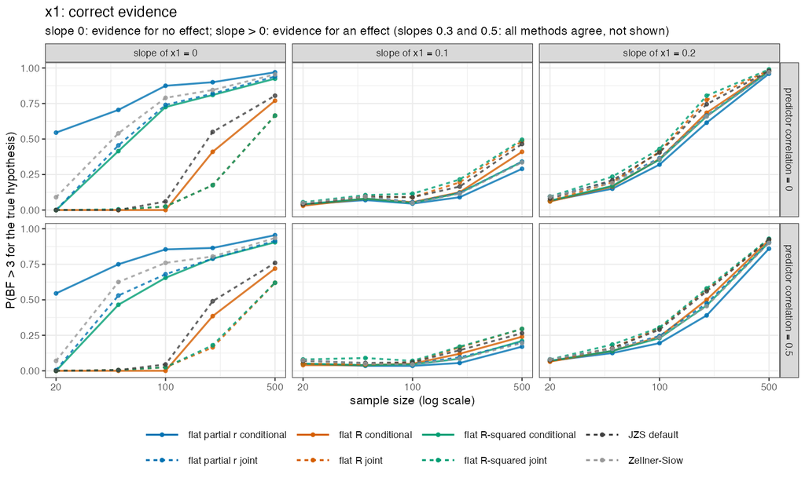

03 correct evidence x1

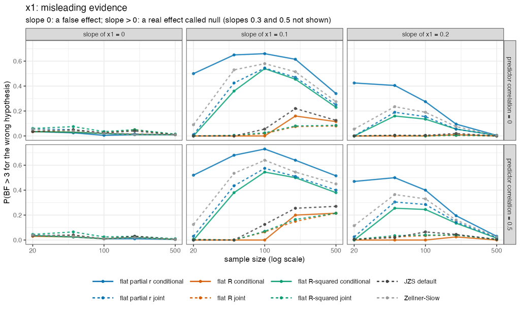

03 misleading evidence x1

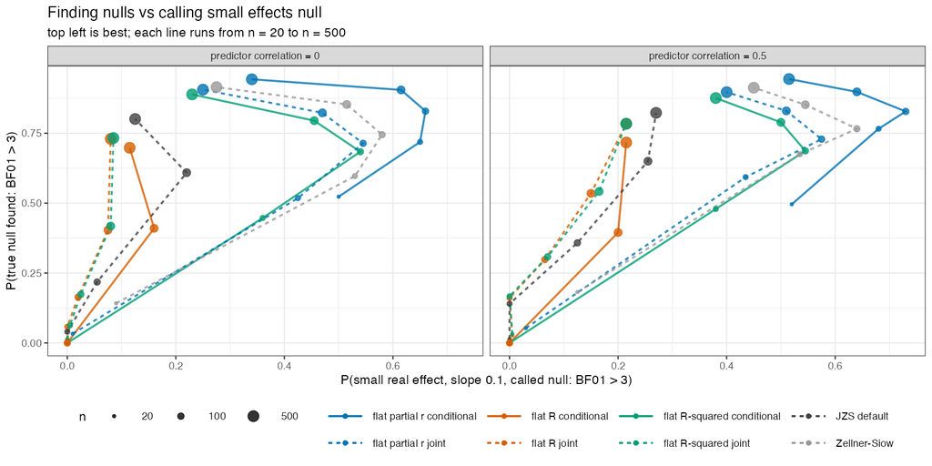

03 trade off

**NoteStudy 04 matched comparison (0 passed, 0 failed)**

| Note |
| --- |
| no pass/fail checks (a comparison study), or no log |

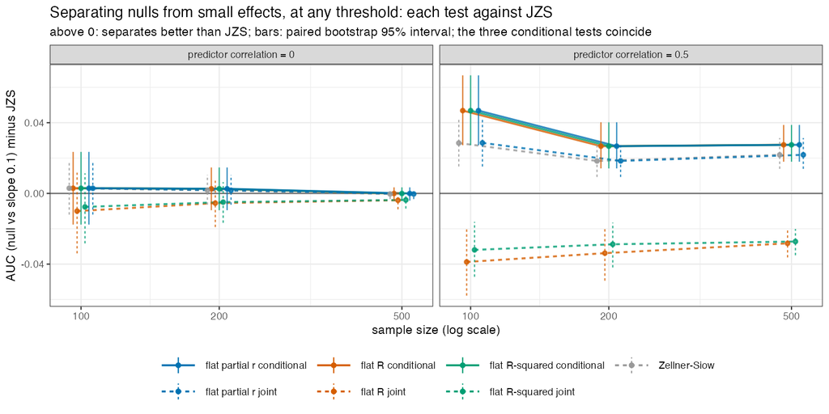

04 discrimination

**NoteStudy 05 conditional test (13 passed, 0 failed)**

| Result | Check |
| --- | --- |
| PASS | C1. k = 1: equals the joint Bayes factor (every prior) \| largest difference 1.8e-06 |
| PASS | C2. implied prior: correlated joint draws = share formula (k = 4; flat_r, flat_r_squared) KS distances 0.0024 0.0021 |
| PASS | C3. exact vs approximate flat partial correlation \| largest difference 0.012 |
| PASS | C4a. flat_partial_r: one partial correlation is flat (k = 2, 5, 12) KS distances 0.0025 0.0022 0.0023 |
| PASS | C4b. share mixture with a = k/2 = flat partial correlation (k = 2-30; blocks) largest difference 1.8e-05 |
| PASS | C5. flat_r: conditional grid = stats::integrate (n 50 to 1e6, k 1 to 30, t 0 to 6) largest difference 6.7e-05 (n = 50, k = 30, t = 4) |
| PASS | C5. flat_partial_r: conditional grid = stats::integrate (n 50 to 1e6, k 1 to 30, t 0 to 6) largest difference 3.5e-06 (n = 50, k = 30, t = 6) |
| PASS | C5. flat_r_squared: conditional grid = stats::integrate (n 50 to 1e6, k 1 to 30, t 0 to 6) largest difference 5.0e-05 (n = 50, k = 30, t = 6) |
| PASS | C7. LKJ(eta): one partial correlation ~ Beta(eta, eta) for k = 1, 3, 8; flat only at eta = 1 KS to Beta(eta, eta): 0.016 0.013 0.013 0.012 0.018 0.014; to flat at eta = 2: 0.097 0.104 0.101 |
| PASS | C8. Kucharský et al. (2026), flat prior: reproduces their BF 45.88; equals ours with the predictor’s residual SD unknown; differs from ours (fixed X) their example 45.877; ours with random predictor -… |
| PASS | C9. block of q columns: flat_partial_r gives partial R^2 ~ Beta(q/2, 1) (LKJ and g-prior draws); flat_r and flat_r_squared give share ~ Beta(q/2, (k-q)/2) largest KS distance: LKJ 0.017, g-prior draws… |
| PASS | C10. block conditional test (every prior) = stats::integrate (q 2 to 5, n 50 to 1e6, F 0 to 6) largest difference 1.0e-04 (flat_partial_r, n = 1e+06, k = 12, q = 5, F = 0) |
| PASS | C11. block likelihood ratio = integration over sigma and direction from the data (q = 2) largest difference 1.6e-14 |

**NoteStudy 06 broad simulation (0 passed, 0 failed)**

| Note |
| --- |
| no pass/fail checks (a comparison study), or no log |

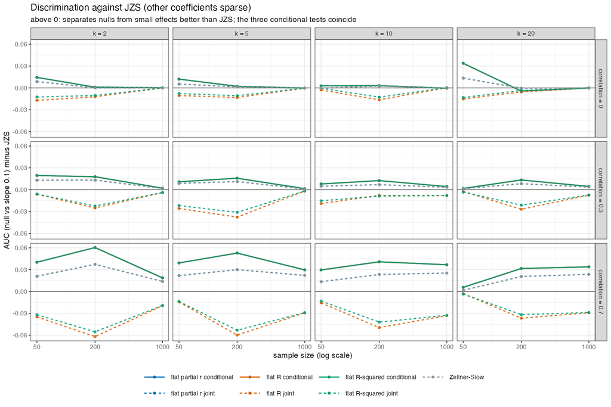

06 auc sparse

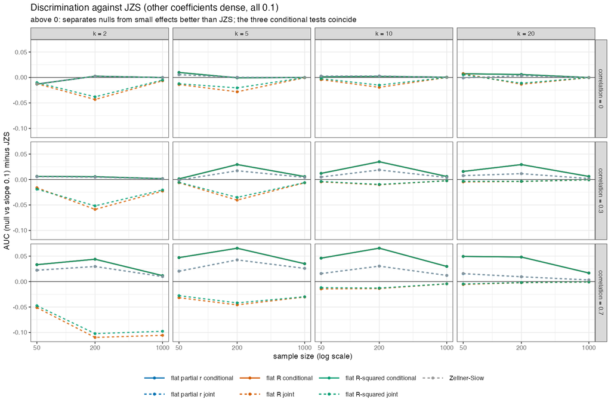

06 auc dense

**NoteStudy 07 estimation (0 passed, 0 failed)**

| Note |
| --- |
| no pass/fail checks (a comparison study), or no log |

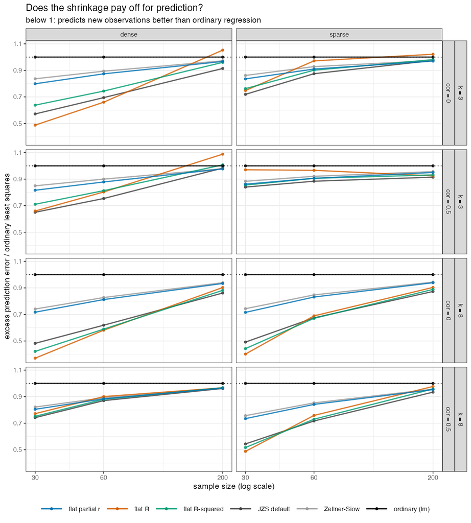

07 prediction error

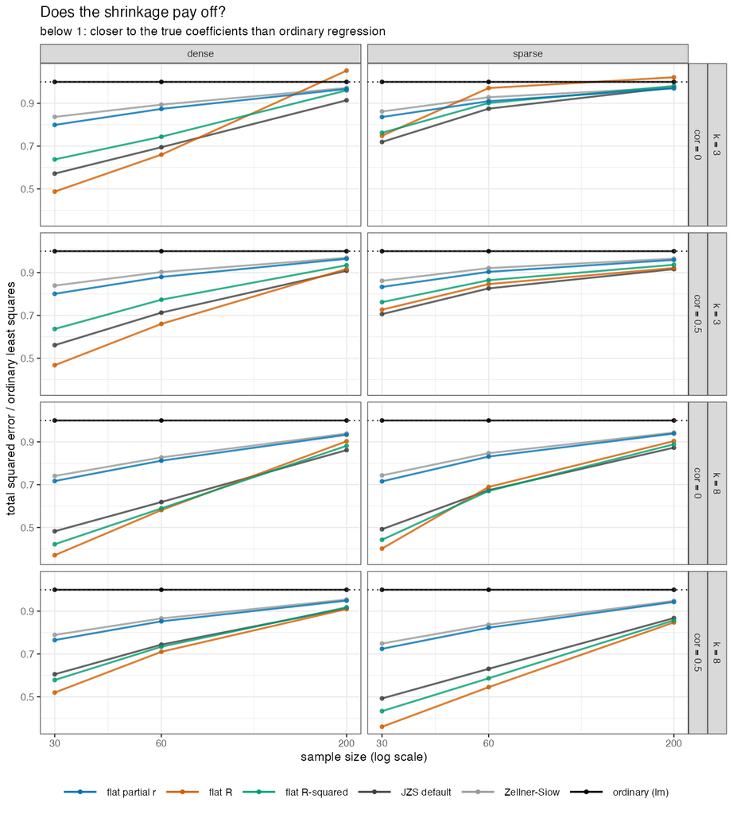

07 relative error

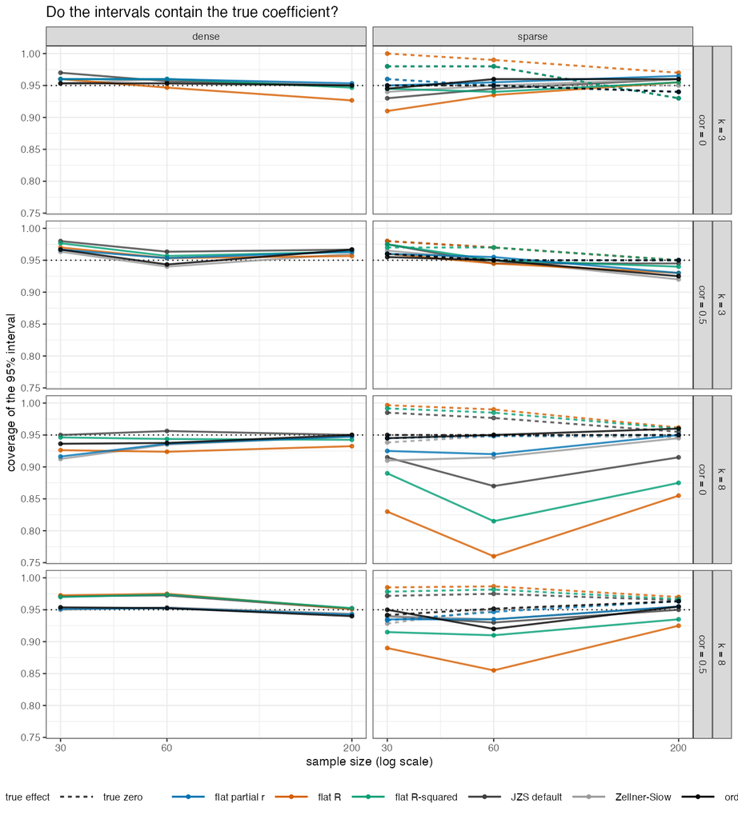

07 coverage

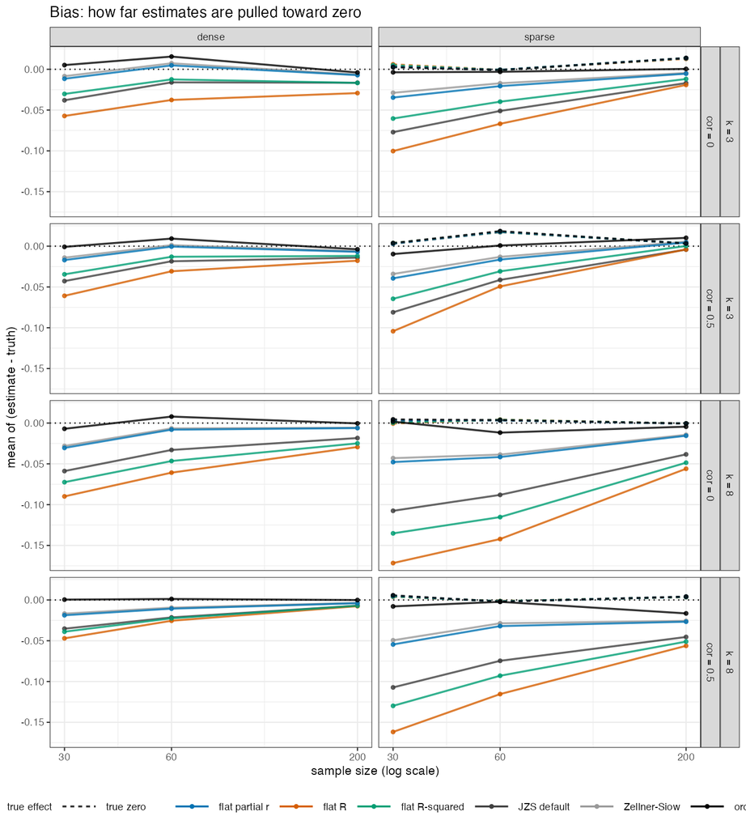

07 bias

**NoteStudy 08 growing k (12 passed, 0 failed)**

| Result | Check |
| --- | --- |
| PASS | G1. flat partial r, k = n / 4, null true: evidence for the null grows median log BF01 at n = 50 … 2000: 8.9 18.5 39.5 100.2 203.6 407.6; slope 98.87 |
| PASS | G2. flat partial r, k = n / 4, small model true: evidence for it grows median log BF at n = 50 … 2000: 6.4 16.8 38.6 104.4 218.1 443.8; slope 108.22 |
| PASS | G1. flat R, k = n / 4, null true: evidence for the null grows median log BF01 at n = 50 … 2000: 1.0 1.1 1.4 1.5 1.8 1.9; slope 0.25 |
| PASS | G2. flat R, k = n / 4, small model true: evidence for it grows median log BF at n = 50 … 2000: 1.8 5.7 14.2 40.3 85.1 174.1; slope 42.65 |
| PASS | G1. flat R-squared, k = n / 4, null true: evidence for the null grows median log BF01 at n = 50 … 2000: 1.9 2.1 2.6 3.0 3.4 3.7; slope 0.50 |
| PASS | G2. flat R-squared, k = n / 4, small model true: evidence for it grows median log BF at n = 50 … 2000: 2.0 5.8 14.3 40.3 85.1 174.1; slope 42.60 |
| PASS | G1. flat partial r, k = sqrt(n), null true: evidence for the null grows median log BF01 at n = 50 … 2000: 6.2 10.9 17.7 33.2 52.9 83.0; slope 19.95 |
| PASS | G2. flat partial r, k = sqrt(n), small model true: evidence for it grows median log BF at n = 50 … 2000: 3.6 7.2 13.6 29.1 48.5 79.3; slope 19.66 |
| PASS | G1. flat R, k = sqrt(n), null true: evidence for the null grows median log BF01 at n = 50 … 2000: 1.1 1.4 1.6 2.0 2.3 2.6; slope 0.40 |
| PASS | G2. flat R, k = sqrt(n), small model true: evidence for it grows median log BF at n = 50 … 2000: 1.3 3.2 7.1 17.0 29.7 51.1; slope 12.86 |
| PASS | G1. flat R-squared, k = sqrt(n), null true: evidence for the null grows median log BF01 at n = 50 … 2000: 2.1 2.7 3.2 3.9 4.5 5.1; slope 0.80 |
| PASS | G2. flat R-squared, k = sqrt(n), small model true: evidence for it grows median log BF at n = 50 … 2000: 1.5 3.3 7.1 17.0 29.7 51.1; slope 12.81 |

**NoteStudy 09 variable selection (5 passed, 0 failed)**

| Result | Check |
| --- | --- |
| PASS | V1. tabulated log BF vs direct (200 random cases) \| largest error 2.8e-06 |
| PASS | V2. Beta(a, 1) version with a = 1/2 equals flat R \| largest difference 7.7e-06 |
| PASS | V3. g-mixture with a = k/2 implies R-squared ~ Beta(k/2, 1) (k = 2, 5, 12) KS distances 0.0017 0.0026 0.0013 |
| PASS | V4. uniformly drawn correlation matrices imply R-squared ~ Beta(k/2, 1) (k = 1, 2, 5) KS distances 0.0106 0.0129 0.0098 |
| PASS | V5. W ~ Inverse-Gamma(b, 1/2) implies R-squared ~ Beta(1/2, b) (b = 1/2, 2; k = 1, 5, 20) KS distances 0.0016 0.0017 0.0025 0.0020 0.0031 0.0020 |

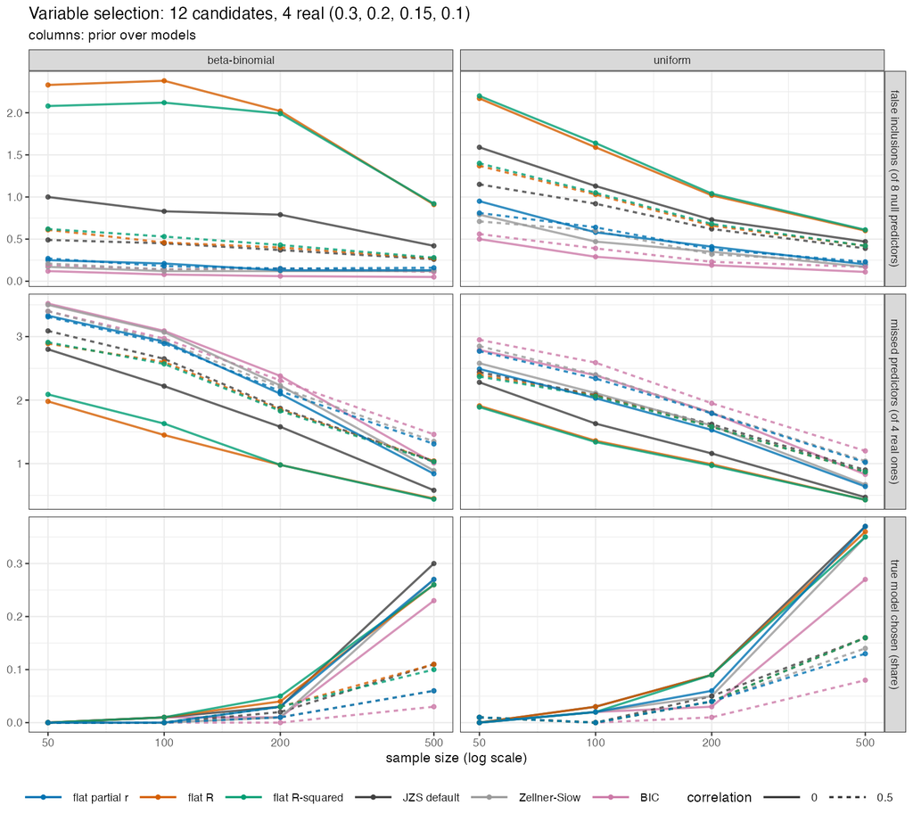

09 variable selection

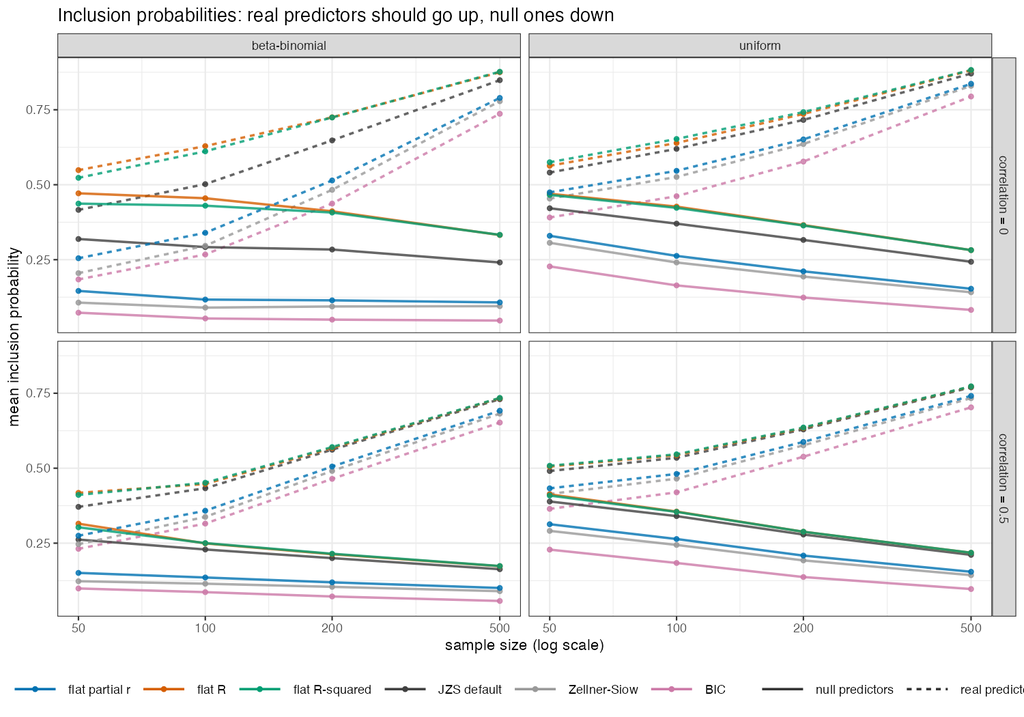

09 inclusion

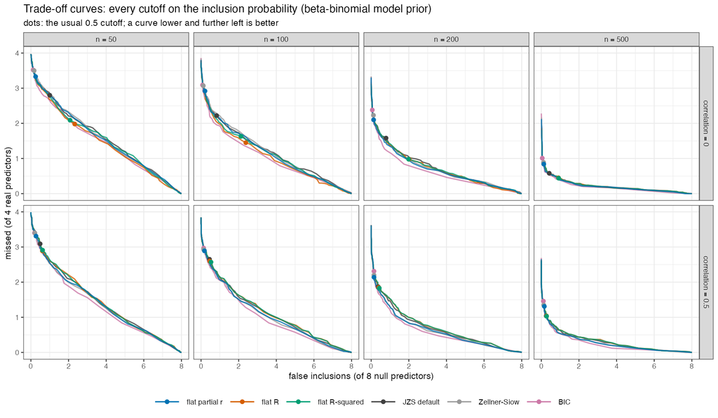

09 trade off curves

**NoteStudy 10 calibration (35 passed, 1 failed)**

| Result | Check |
| --- | --- |
| PASS | P1. flat partial r: calibrated on its own prior, k = 3, n = 200 chi2 = 8.5 on 11 bins (p = 0.67); slope 0.993 (SE 0.022) |
| PASS | P1. flat partial r: calibrated on its own prior, k = 3, n = 50 chi2 = 11.5 on 11 bins (p = 0.40); slope 0.981 (SE 0.020) |
| PASS | P1. flat partial r: calibrated on its own prior, k = 8, n = 200 chi2 = 9.9 on 11 bins (p = 0.54); slope 1.034 (SE 0.023) |
| PASS | P1. flat partial r: calibrated on its own prior, k = 8, n = 50 chi2 = 7.2 on 11 bins (p = 0.79); slope 1.010 (SE 0.020) |
| PASS | P1. flat R: calibrated on its own prior, k = 3, n = 200 chi2 = 4.9 on 9 bins (p = 0.84); slope 0.985 (SE 0.023) |
| PASS | P1. flat R: calibrated on its own prior, k = 3, n = 50 \| chi2 = 2.0 on 8 bins (p = 0.98); slope 0.991 (SE 0.024) |
| PASS | P1. flat R: calibrated on its own prior, k = 8, n = 200 chi2 = 7.1 on 8 bins (p = 0.52); slope 1.017 (SE 0.025) |
| PASS | P1. flat R: calibrated on its own prior, k = 8, n = 50 \| chi2 = 2.7 on 8 bins (p = 0.95); slope 0.995 (SE 0.028) |
| PASS | P1. flat R-squared: calibrated on its own prior, k = 3, n = 200 chi2 = 6.2 on 11 bins (p = 0.86); slope 1.011 (SE 0.022) |
| PASS | P1. flat R-squared: calibrated on its own prior, k = 3, n = 50 chi2 = 9.8 on 9 bins (p = 0.37); slope 1.004 (SE 0.021) |
| PASS | P1. flat R-squared: calibrated on its own prior, k = 8, n = 200 chi2 = 3.5 on 9 bins (p = 0.94); slope 1.016 (SE 0.022) |
| PASS | P1. flat R-squared: calibrated on its own prior, k = 8, n = 50 chi2 = 5.1 on 8 bins (p = 0.74); slope 0.983 (SE 0.022) |
| PASS | P2. flat partial r, data from JZS: miscalibration shows, k = 3, n = 200 chi2 = 519 on 11 bins; slope 0.95 (SE 0.02) |
| PASS | P2. flat partial r, data from JZS: miscalibration shows, k = 3, n = 50 chi2 = 519 on 10 bins; slope 0.89 (SE 0.02) |
| PASS | P2. flat partial r, data from JZS: miscalibration shows, k = 8, n = 200 chi2 = 556 on 11 bins; slope 0.94 (SE 0.02) |
| PASS | P2. flat partial r, data from JZS: miscalibration shows, k = 8, n = 50 chi2 = 503 on 10 bins; slope 0.90 (SE 0.02) |
| PASS | P2. flat R, data from JZS: miscalibration shows, k = 3, n = 200 chi2 = 388 on 9 bins; slope 1.16 (SE 0.03) |
| PASS | P2. flat R, data from JZS: miscalibration shows, k = 3, n = 50 chi2 = 233 on 8 bins; slope 1.17 (SE 0.03) |
| PASS | P2. flat R, data from JZS: miscalibration shows, k = 8, n = 200 chi2 = 1198 on 8 bins; slope 1.27 (SE 0.03) |
| PASS | P2. flat R, data from JZS: miscalibration shows, k = 8, n = 50 chi2 = 857 on 8 bins; slope 1.41 (SE 0.03) |
| PASS | P2. flat R-squared, data from JZS: miscalibration shows, k = 3, n = 200 chi2 = 50 on 11 bins; slope 0.99 (SE 0.02) |
| PASS | P2. flat R-squared, data from JZS: miscalibration shows, k = 3, n = 50 chi2 = 70 on 9 bins; slope 0.95 (SE 0.02) |
| PASS | P2. flat R-squared, data from JZS: miscalibration shows, k = 8, n = 200 chi2 = 265 on 9 bins; slope 1.06 (SE 0.02) |
| PASS | P2. flat R-squared, data from JZS: miscalibration shows, k = 8, n = 50 chi2 = 235 on 8 bins; slope 1.12 (SE 0.02) |
| PASS | P3. flat partial r: Savage-Dickey, logspline and kernel agree (estimable ones) 16 of 20 estimable; largest difference 0.101 |
| PASS | P4. flat partial r: conditional within a factor 2 of Savage-Dickey (estimable) largest \|difference\| 0.092 on the log scale (factor 1.10); mean \|difference\| 0.028 |
| PASS | P5. flat partial r: the others, conditional within 3 Monte Carlo SE of Savage-Dickey 4.98 vs 4.39 (SE 0.27); 2.98 vs 2.82 (SE 0.15); 8.97 vs 8.33 (SE 0.70); 1.96 vs 2.17 (SE 0.12) |
| PASS | P3. flat R-squared: Savage-Dickey, logspline and kernel agree (estimable ones) 19 of 20 estimable; largest difference 0.182 |
| FAIL | P4. flat R-squared: conditional within a factor 2 of Savage-Dickey (estimable) largest \|difference\| 0.874 on the log scale (factor 2.40); mean \|difference\| 0.283 |
| PASS | P5. flat R-squared: the others, conditional within 3 Monte Carlo SE of Savage-Dickey 3.01 vs 3.37 (SE 0.12) |
| PASS | P6. flat_partial_r, k = 3: rho1 = 0 is a proper restriction density near 0: 0.498 0.502 0.485; others’ median R^2: 0.372 0.372 0.374 |
| PASS | P6. flat_r_squared, k = 3: rho1 = 0 is a proper restriction density near 0: 0.741 0.767 0.781; others’ median R^2: 0.185 0.169 0.180 |
| PASS | P7. flat_r, k = 3: rho1 = 0 drags the others to 0 \| density near 0: 1.506 2.301 2.990; others’ median R^2: 0.024 0.005 0.001 |
| PASS | P6. flat_partial_r, k = 8: rho1 = 0 is a proper restriction density near 0: 0.504 0.497 0.491; others’ median R^2: 0.730 0.733 0.728 |
| PASS | P6. flat_r_squared, k = 8: rho1 = 0 is a proper restriction density near 0: 1.342 1.537 1.558; others’ median R^2: 0.221 0.174 0.162 |
| PASS | P7. flat_r, k = 8: rho1 = 0 drags the others to 0 \| density near 0: 2.229 3.827 5.204; others’ median R^2: 0.054 0.012 0.003 |

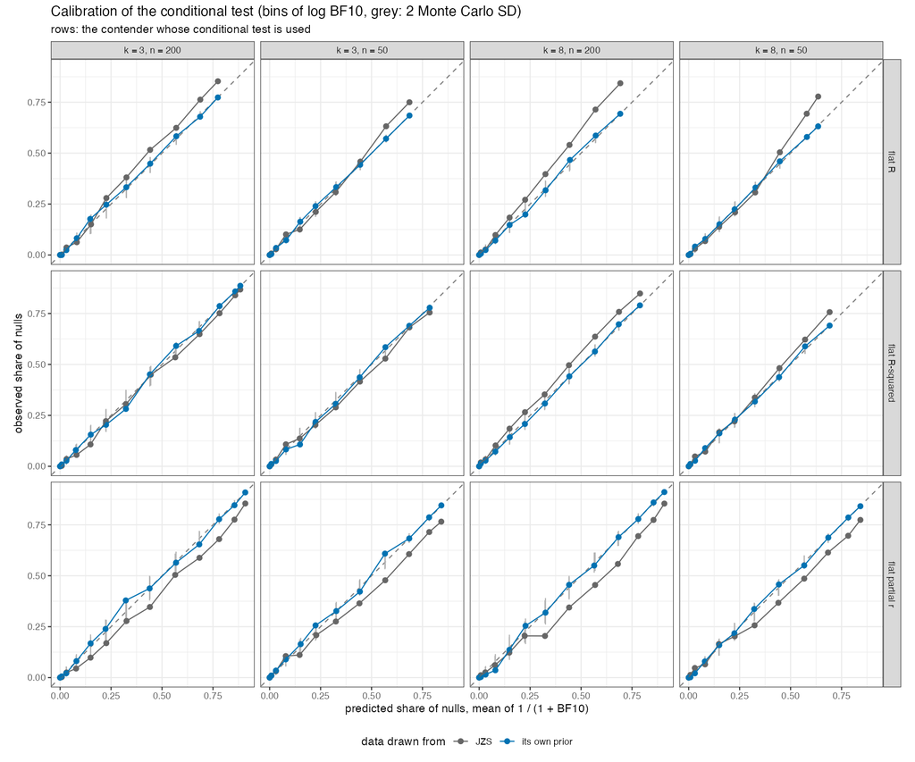

10 calibration

**NoteStudy 11 factor terms (3 passed, 0 failed)**

| Result | Check |
| --- | --- |
| PASS | F1 conditional: same for every R2 of the others \| largest difference in log BF10 1.4e-12 (14400 datasets, three contenders) |
| PASS | F2 the three conditional tests: same AUC \| largest difference 0.0e+00 over 72 cells |
| PASS | F3 JZS (lmBF): proportional error < 0.05 \| median 0.0084, 99% 0.0192, largest 0.032 |

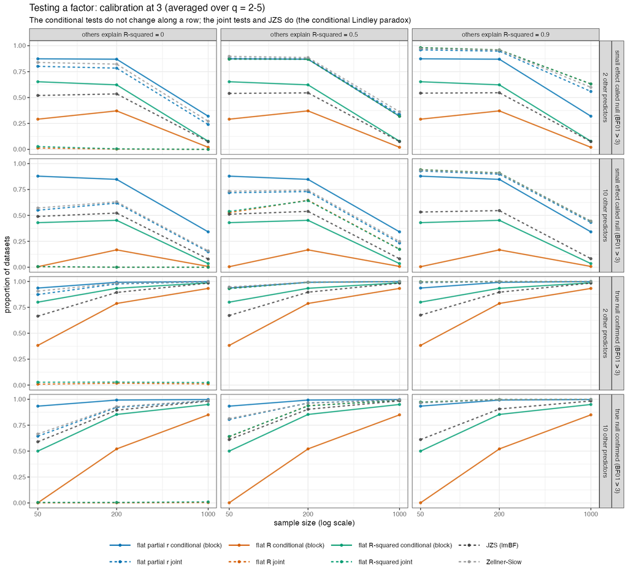

11 calibration

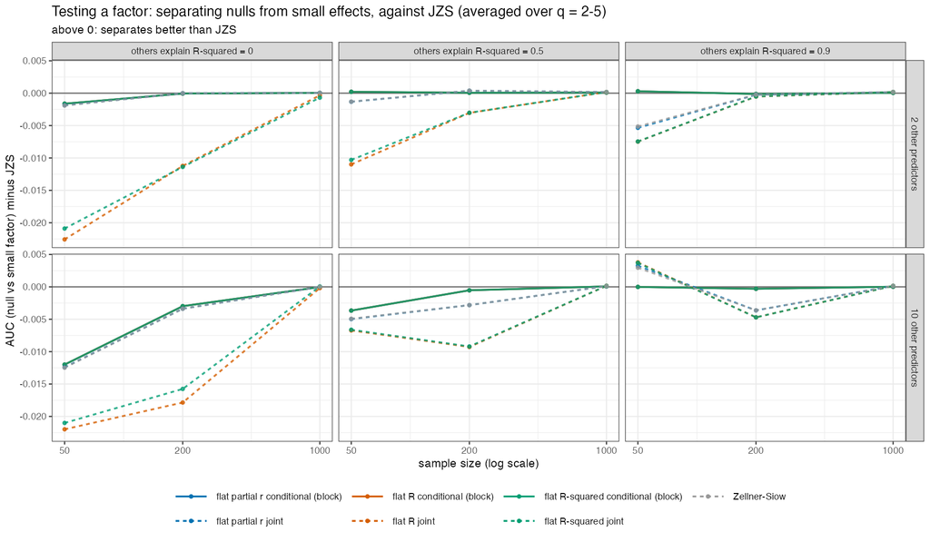

11 auc